# Optimal Treatment Analysis

## Outcome Variable

**Outcome Variable:** whz

## Predictor Variables

**Intervention Variable:** predfeed6

**Adjustment Set:**

- arm
- sex
- month
- brthmon
- W_mage
- meducyrs
- feducyrs
- hhwealth_quart
- hfoodsec
- W_mhtcm
- vagbrth
- W_gagebrth
- W_birthwt
- W_birthlen
- W_nrooms
- W_nchldlt5
- W_parity
- impfloor
- impsan
- safeh20
- delta_W_mage
- delta_meducyrs
- delta_feducyrs
- delta_hhwealth_quart
- delta_hfoodsec
- delta_W_mhtcm
- delta_vagbrth
- delta_W_gagebrth
- delta_W_birthwt
- delta_W_birthlen
- delta_W_nrooms
- delta_W_nchldlt5
- delta_W_parity
- delta_impfloor
- delta_impsan
- delta_safeh20

## Stratifying Variables

The analysis was stratified on these variable(s):

- agecat
- studyid
- country

## Data Summary

| agecat | studyid | country | predfeed6 | n_cell | n |
| --- | --- | --- | --- | --- | --- |
| Birth | ki0047075b-MAL-ED | BANGLADESH | 1 | 114 | 219 |
| Birth | ki0047075b-MAL-ED | BANGLADESH | 0 | 105 | 219 |
| Birth | ki0047075b-MAL-ED | BRAZIL | 1 | 26 | 168 |
| Birth | ki0047075b-MAL-ED | BRAZIL | 0 | 142 | 168 |
| Birth | ki0047075b-MAL-ED | INDIA | 1 | 15 | 187 |
| Birth | ki0047075b-MAL-ED | INDIA | 0 | 172 | 187 |
| Birth | ki0047075b-MAL-ED | NEPAL | 1 | 22 | 165 |
| Birth | ki0047075b-MAL-ED | NEPAL | 0 | 143 | 165 |
| Birth | ki0047075b-MAL-ED | PERU | 1 | 104 | 249 |
| Birth | ki0047075b-MAL-ED | PERU | 0 | 145 | 249 |
| Birth | ki0047075b-MAL-ED | SOUTH AFRICA | 1 | 3 | 209 |
| Birth | ki0047075b-MAL-ED | SOUTH AFRICA | 0 | 206 | 209 |
| Birth | ki0047075b-MAL-ED | TANZANIA, UNITED REPUBLIC OF | 1 | 1 | 115 |
| Birth | ki0047075b-MAL-ED | TANZANIA, UNITED REPUBLIC OF | 0 | 114 | 115 |
| Birth | ki1000109-EE | PAKISTAN | 1 | 0 | 1 |
| Birth | ki1000109-EE | PAKISTAN | 0 | 1 | 1 |
| Birth | kiGH5241-JiVitA-3 | BANGLADESH | 1 | 5982 | 7550 |
| Birth | kiGH5241-JiVitA-3 | BANGLADESH | 0 | 1568 | 7550 |
| Birth | kiGH5241-JiVitA-4 | BANGLADESH | 1 | 142 | 170 |
| Birth | kiGH5241-JiVitA-4 | BANGLADESH | 0 | 28 | 170 |
| 6 months | ki0047075b-MAL-ED | BANGLADESH | 1 | 123 | 235 |
| 6 months | ki0047075b-MAL-ED | BANGLADESH | 0 | 112 | 235 |
| 6 months | ki0047075b-MAL-ED | BRAZIL | 1 | 35 | 209 |
| 6 months | ki0047075b-MAL-ED | BRAZIL | 0 | 174 | 209 |
| 6 months | ki0047075b-MAL-ED | INDIA | 1 | 18 | 232 |
| 6 months | ki0047075b-MAL-ED | INDIA | 0 | 214 | 232 |
| 6 months | ki0047075b-MAL-ED | NEPAL | 1 | 29 | 235 |
| 6 months | ki0047075b-MAL-ED | NEPAL | 0 | 206 | 235 |
| 6 months | ki0047075b-MAL-ED | PERU | 1 | 113 | 269 |
| 6 months | ki0047075b-MAL-ED | PERU | 0 | 156 | 269 |
| 6 months | ki0047075b-MAL-ED | SOUTH AFRICA | 1 | 3 | 242 |
| 6 months | ki0047075b-MAL-ED | SOUTH AFRICA | 0 | 239 | 242 |
| 6 months | ki0047075b-MAL-ED | TANZANIA, UNITED REPUBLIC OF | 1 | 2 | 244 |
| 6 months | ki0047075b-MAL-ED | TANZANIA, UNITED REPUBLIC OF | 0 | 242 | 244 |
| 6 months | ki1000109-EE | PAKISTAN | 1 | 220 | 376 |
| 6 months | ki1000109-EE | PAKISTAN | 0 | 156 | 376 |
| 6 months | ki1000304b-SAS-FoodSuppl | INDIA | 1 | 0 | 43 |
| 6 months | ki1000304b-SAS-FoodSuppl | INDIA | 0 | 43 | 43 |
| 6 months | ki1113344-GMS-Nepal | NEPAL | 1 | 404 | 546 |
| 6 months | ki1113344-GMS-Nepal | NEPAL | 0 | 142 | 546 |
| 6 months | ki1148112-LCNI-5 | MALAWI | 1 | 47 | 272 |
| 6 months | ki1148112-LCNI-5 | MALAWI | 0 | 225 | 272 |
| 6 months | kiGH5241-JiVitA-3 | BANGLADESH | 1 | 6455 | 8247 |
| 6 months | kiGH5241-JiVitA-3 | BANGLADESH | 0 | 1792 | 8247 |
| 6 months | kiGH5241-JiVitA-4 | BANGLADESH | 1 | 861 | 1079 |
| 6 months | kiGH5241-JiVitA-4 | BANGLADESH | 0 | 218 | 1079 |
| 24 months | ki0047075b-MAL-ED | BANGLADESH | 1 | 112 | 209 |
| 24 months | ki0047075b-MAL-ED | BANGLADESH | 0 | 97 | 209 |
| 24 months | ki0047075b-MAL-ED | BRAZIL | 1 | 29 | 169 |
| 24 months | ki0047075b-MAL-ED | BRAZIL | 0 | 140 | 169 |
| 24 months | ki0047075b-MAL-ED | INDIA | 1 | 17 | 224 |
| 24 months | ki0047075b-MAL-ED | INDIA | 0 | 207 | 224 |
| 24 months | ki0047075b-MAL-ED | NEPAL | 1 | 28 | 227 |
| 24 months | ki0047075b-MAL-ED | NEPAL | 0 | 199 | 227 |
| 24 months | ki0047075b-MAL-ED | PERU | 1 | 84 | 198 |
| 24 months | ki0047075b-MAL-ED | PERU | 0 | 114 | 198 |
| 24 months | ki0047075b-MAL-ED | SOUTH AFRICA | 1 | 3 | 227 |
| 24 months | ki0047075b-MAL-ED | SOUTH AFRICA | 0 | 224 | 227 |
| 24 months | ki0047075b-MAL-ED | TANZANIA, UNITED REPUBLIC OF | 1 | 2 | 212 |
| 24 months | ki0047075b-MAL-ED | TANZANIA, UNITED REPUBLIC OF | 0 | 210 | 212 |
| 24 months | ki1113344-GMS-Nepal | NEPAL | 1 | 359 | 479 |
| 24 months | ki1113344-GMS-Nepal | NEPAL | 0 | 120 | 479 |
| 24 months | ki1148112-LCNI-5 | MALAWI | 1 | 34 | 184 |
| 24 months | ki1148112-LCNI-5 | MALAWI | 0 | 150 | 184 |
| 24 months | kiGH5241-JiVitA-3 | BANGLADESH | 1 | 3288 | 4239 |
| 24 months | kiGH5241-JiVitA-3 | BANGLADESH | 0 | 951 | 4239 |
| 24 months | kiGH5241-JiVitA-4 | BANGLADESH | 1 | 860 | 1074 |
| 24 months | kiGH5241-JiVitA-4 | BANGLADESH | 0 | 214 | 1074 |

The following strata were considered:

- agecat: 24 months, studyid: ki0047075b-MAL-ED, country: BANGLADESH
- agecat: 24 months, studyid: ki0047075b-MAL-ED, country: BRAZIL
- agecat: 24 months, studyid: ki0047075b-MAL-ED, country: INDIA
- agecat: 24 months, studyid: ki0047075b-MAL-ED, country: NEPAL
- agecat: 24 months, studyid: ki0047075b-MAL-ED, country: PERU
- agecat: 24 months, studyid: ki0047075b-MAL-ED, country: SOUTH AFRICA
- agecat: 24 months, studyid: ki0047075b-MAL-ED, country: TANZANIA, UNITED REPUBLIC OF
- agecat: 24 months, studyid: ki1113344-GMS-Nepal, country: NEPAL
- agecat: 24 months, studyid: ki1148112-LCNI-5, country: MALAWI
- agecat: 24 months, studyid: kiGH5241-JiVitA-3, country: BANGLADESH
- agecat: 24 months, studyid: kiGH5241-JiVitA-4, country: BANGLADESH
- agecat: 6 months, studyid: ki0047075b-MAL-ED, country: BANGLADESH
- agecat: 6 months, studyid: ki0047075b-MAL-ED, country: BRAZIL
- agecat: 6 months, studyid: ki0047075b-MAL-ED, country: INDIA
- agecat: 6 months, studyid: ki0047075b-MAL-ED, country: NEPAL
- agecat: 6 months, studyid: ki0047075b-MAL-ED, country: PERU
- agecat: 6 months, studyid: ki0047075b-MAL-ED, country: SOUTH AFRICA
- agecat: 6 months, studyid: ki0047075b-MAL-ED, country: TANZANIA, UNITED REPUBLIC OF
- agecat: 6 months, studyid: ki1000109-EE, country: PAKISTAN
- agecat: 6 months, studyid: ki1000304b-SAS-FoodSuppl, country: INDIA
- agecat: 6 months, studyid: ki1113344-GMS-Nepal, country: NEPAL
- agecat: 6 months, studyid: ki1148112-LCNI-5, country: MALAWI
- agecat: 6 months, studyid: kiGH5241-JiVitA-3, country: BANGLADESH
- agecat: 6 months, studyid: kiGH5241-JiVitA-4, country: BANGLADESH
- agecat: Birth, studyid: ki0047075b-MAL-ED, country: BANGLADESH
- agecat: Birth, studyid: ki0047075b-MAL-ED, country: BRAZIL
- agecat: Birth, studyid: ki0047075b-MAL-ED, country: INDIA
- agecat: Birth, studyid: ki0047075b-MAL-ED, country: NEPAL
- agecat: Birth, studyid: ki0047075b-MAL-ED, country: PERU
- agecat: Birth, studyid: ki0047075b-MAL-ED, country: SOUTH AFRICA
- agecat: Birth, studyid: ki0047075b-MAL-ED, country: TANZANIA, UNITED REPUBLIC OF
- agecat: Birth, studyid: ki1000109-EE, country: PAKISTAN
- agecat: Birth, studyid: kiGH5241-JiVitA-3, country: BANGLADESH
- agecat: Birth, studyid: kiGH5241-JiVitA-4, country: BANGLADESH

### Dropped Strata

Some strata were dropped due to rare outcomes:

- agecat: Birth, studyid: ki0047075b-MAL-ED, country: SOUTH AFRICA
- agecat: Birth, studyid: ki0047075b-MAL-ED, country: TANZANIA, UNITED REPUBLIC OF
- agecat: Birth, studyid: ki1000109-EE, country: PAKISTAN
- agecat: 6 months, studyid: ki0047075b-MAL-ED, country: SOUTH AFRICA
- agecat: 6 months, studyid: ki0047075b-MAL-ED, country: TANZANIA, UNITED REPUBLIC OF
- agecat: 6 months, studyid: ki1000304b-SAS-FoodSuppl, country: INDIA
- agecat: 24 months, studyid: ki0047075b-MAL-ED, country: SOUTH AFRICA
- agecat: 24 months, studyid: ki0047075b-MAL-ED, country: TANZANIA, UNITED REPUBLIC OF

## Methods Detail

We’re interested in the causal parameters $E[Y_a]$ for all values of $a \in \mathcal{A}$. These parameters represent the mean outcome if, possibly contrary to fact, we intervened to set all units to have $A=a$. Under the randomization and positivity assumptions, these are identified by the statistical parameters $\psi_a=E_W[E_{Y|A,W}(Y|A=a,W)]$. In addition, we’re interested in the mean of $Y$, $E[Y]$ under no intervention (the observed mean). We will estimate these parameters by using SuperLearner to fit the relevant likelihood factors – $E_{Y|A,W}(Y|A=a,W)$ and $p(A=a|W)$, and then updating our likelihood fit using a joint TMLE.

For unadjusted analyses ($W=\{\}$), initial likelihoods were estimated using Lrnr_glm to estimate the simple $E(Y|A)$ and Lrnr_mean to estimate $p(A)$. For adjusted analyses, a small library containing Lrnr_glmnet, Lrnr_xgboost, and Lrnr_mean was used.

Having estimated these parameters, we will then use the delta method to estimate relative risks and attributable risks relative to a prespecified baseline level of $A$.

# Results Detail

## Results Plots

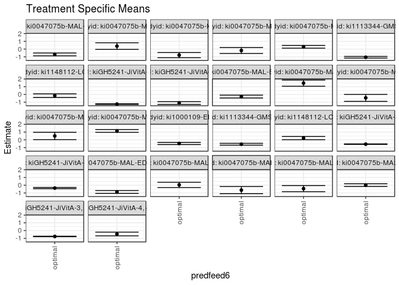

## Results Table

### Parameter: TSM

| agecat | studyid | country | intervention_level | baseline_level | estimate | ci_lower | ci_upper |
| --- | --- | --- | --- | --- | --- | --- | --- |
| Birth | ki0047075b-MAL-ED | BANGLADESH | optimal | observed | -0.8695009 | -1.0525411 | -0.6864608 |
| Birth | ki0047075b-MAL-ED | BRAZIL | optimal | observed | 0.0382047 | -0.2984579 | 0.3748673 |
| Birth | ki0047075b-MAL-ED | INDIA | optimal | observed | -0.6330913 | -1.0974482 | -0.1687343 |
| Birth | ki0047075b-MAL-ED | NEPAL | optimal | observed | -0.4393268 | -0.8340028 | -0.0446509 |
| Birth | ki0047075b-MAL-ED | PERU | optimal | observed | 0.0130070 | -0.1635930 | 0.1896070 |
| Birth | kiGH5241-JiVitA-3 | BANGLADESH | optimal | observed | -0.7538826 | -0.7833505 | -0.7244146 |
| Birth | kiGH5241-JiVitA-4 | BANGLADESH | optimal | observed | -0.4403708 | -0.6835486 | -0.1971930 |
| 6 months | ki0047075b-MAL-ED | BANGLADESH | optimal | observed | -0.2738629 | -0.4591619 | -0.0885639 |
| 6 months | ki0047075b-MAL-ED | BRAZIL | optimal | observed | 1.4616030 | 1.0617923 | 1.8614138 |
| 6 months | ki0047075b-MAL-ED | INDIA | optimal | observed | -0.4417462 | -0.8886123 | 0.0051199 |
| 6 months | ki0047075b-MAL-ED | NEPAL | optimal | observed | 0.5005339 | 0.0208452 | 0.9802226 |
| 6 months | ki0047075b-MAL-ED | PERU | optimal | observed | 1.1453728 | 0.9707768 | 1.3199689 |
| 6 months | ki1000109-EE | PAKISTAN | optimal | observed | -0.4694235 | -0.6107437 | -0.3281033 |
| 6 months | ki1113344-GMS-Nepal | NEPAL | optimal | observed | -0.5669592 | -0.6857838 | -0.4481345 |
| 6 months | ki1148112-LCNI-5 | MALAWI | optimal | observed | 0.2260765 | 0.0107342 | 0.4414189 |
| 6 months | kiGH5241-JiVitA-3 | BANGLADESH | optimal | observed | -0.5577327 | -0.5879861 | -0.5274793 |
| 6 months | kiGH5241-JiVitA-4 | BANGLADESH | optimal | observed | -0.3694978 | -0.4532514 | -0.2857441 |
| 24 months | ki0047075b-MAL-ED | BANGLADESH | optimal | observed | -0.6912312 | -0.8722312 | -0.5102313 |
| 24 months | ki0047075b-MAL-ED | BRAZIL | optimal | observed | 0.3834760 | -0.0401314 | 0.8070835 |
| 24 months | ki0047075b-MAL-ED | INDIA | optimal | observed | -0.7797093 | -1.1170620 | -0.4423567 |
| 24 months | ki0047075b-MAL-ED | NEPAL | optimal | observed | -0.1872925 | -0.5717171 | 0.1971320 |
| 24 months | ki0047075b-MAL-ED | PERU | optimal | observed | 0.2938960 | 0.1190545 | 0.4687375 |
| 24 months | ki1113344-GMS-Nepal | NEPAL | optimal | observed | -1.0570436 | -1.1642700 | -0.9498172 |
| 24 months | ki1148112-LCNI-5 | MALAWI | optimal | observed | -0.1573450 | -0.3925938 | 0.0779037 |
| 24 months | kiGH5241-JiVitA-3 | BANGLADESH | optimal | observed | -1.2487282 | -1.3053549 | -1.1921016 |
| 24 months | kiGH5241-JiVitA-4 | BANGLADESH | optimal | observed | -1.1041652 | -1.2815643 | -0.9267660 |

### Parameter: E(Y)

| agecat | studyid | country | intervention_level | baseline_level | estimate | ci_lower | ci_upper |
| --- | --- | --- | --- | --- | --- | --- | --- |
| Birth | ki0047075b-MAL-ED | BANGLADESH | observed | observed | -0.9925114 | -1.1346572 | -0.8503656 |
| Birth | ki0047075b-MAL-ED | BRAZIL | observed | observed | 0.4073214 | 0.2229599 | 0.5916830 |
| Birth | ki0047075b-MAL-ED | INDIA | observed | observed | -1.0435829 | -1.1865715 | -0.9005943 |
| Birth | ki0047075b-MAL-ED | NEPAL | observed | observed | -0.9226061 | -1.0630064 | -0.7822058 |
| Birth | ki0047075b-MAL-ED | PERU | observed | observed | -0.0430924 | -0.1600210 | 0.0738362 |
| Birth | kiGH5241-JiVitA-3 | BANGLADESH | observed | observed | -0.7669854 | -0.7938211 | -0.7401498 |
| Birth | kiGH5241-JiVitA-4 | BANGLADESH | observed | observed | -0.3155294 | -0.4783099 | -0.1527490 |
| 6 months | ki0047075b-MAL-ED | BANGLADESH | observed | observed | -0.1464929 | -0.2779745 | -0.0150113 |
| 6 months | ki0047075b-MAL-ED | BRAZIL | observed | observed | 0.9717225 | 0.8073791 | 1.1360658 |
| 6 months | ki0047075b-MAL-ED | INDIA | observed | observed | -0.7028736 | -0.8283047 | -0.5774424 |
| 6 months | ki0047075b-MAL-ED | NEPAL | observed | observed | 0.1167518 | -0.0146454 | 0.2481490 |
| 6 months | ki0047075b-MAL-ED | PERU | observed | observed | 1.0554461 | 0.9322755 | 1.1786167 |
| 6 months | ki1000109-EE | PAKISTAN | observed | observed | -0.7212766 | -0.8346857 | -0.6078675 |
| 6 months | ki1113344-GMS-Nepal | NEPAL | observed | observed | -0.6015049 | -0.6892785 | -0.5137313 |
| 6 months | ki1148112-LCNI-5 | MALAWI | observed | observed | 0.3927574 | 0.2737700 | 0.5117448 |
| 6 months | kiGH5241-JiVitA-3 | BANGLADESH | observed | observed | -0.5893258 | -0.6167702 | -0.5618814 |
| 6 months | kiGH5241-JiVitA-4 | BANGLADESH | observed | observed | -0.3928452 | -0.4714518 | -0.3142387 |
| 24 months | ki0047075b-MAL-ED | BANGLADESH | observed | observed | -0.8315789 | -0.9546058 | -0.7085521 |
| 24 months | ki0047075b-MAL-ED | BRAZIL | observed | observed | 0.4466272 | 0.2416144 | 0.6516401 |
| 24 months | ki0047075b-MAL-ED | INDIA | observed | observed | -0.9390848 | -1.0545919 | -0.8235777 |
| 24 months | ki0047075b-MAL-ED | NEPAL | observed | observed | -0.3703084 | -0.4835704 | -0.2570464 |
| 24 months | ki0047075b-MAL-ED | PERU | observed | observed | 0.1430051 | 0.0254144 | 0.2605957 |
| 24 months | ki1113344-GMS-Nepal | NEPAL | observed | observed | -1.1369520 | -1.2269975 | -1.0469065 |
| 24 months | ki1148112-LCNI-5 | MALAWI | observed | observed | -0.0771196 | -0.2204715 | 0.0662323 |
| 24 months | kiGH5241-JiVitA-3 | BANGLADESH | observed | observed | -1.2929417 | -1.3253338 | -1.2605497 |
| 24 months | kiGH5241-JiVitA-4 | BANGLADESH | observed | observed | -1.2435289 | -1.3099081 | -1.1771496 |

### Parameter: PAR

| agecat | studyid | country | intervention_level | baseline_level | estimate | ci_lower | ci_upper |
| --- | --- | --- | --- | --- | --- | --- | --- |
| Birth | ki0047075b-MAL-ED | BANGLADESH | optimal | observed | -0.1230105 | -0.2616661 | 0.0156452 |
| Birth | ki0047075b-MAL-ED | BRAZIL | optimal | observed | 0.3691167 | 0.0622700 | 0.6759634 |
| Birth | ki0047075b-MAL-ED | INDIA | optimal | observed | -0.4104916 | -0.8623853 | 0.0414020 |
| Birth | ki0047075b-MAL-ED | NEPAL | optimal | observed | -0.4832792 | -0.8535822 | -0.1129763 |
| Birth | ki0047075b-MAL-ED | PERU | optimal | observed | -0.0560994 | -0.1946891 | 0.0824903 |
| Birth | kiGH5241-JiVitA-3 | BANGLADESH | optimal | observed | -0.0131029 | -0.0253816 | -0.0008241 |
| Birth | kiGH5241-JiVitA-4 | BANGLADESH | optimal | observed | 0.1248414 | -0.0387306 | 0.2884134 |
| 6 months | ki0047075b-MAL-ED | BANGLADESH | optimal | observed | 0.1273700 | -0.0095710 | 0.2643110 |
| 6 months | ki0047075b-MAL-ED | BRAZIL | optimal | observed | -0.4898805 | -0.8576240 | -0.1221370 |
| 6 months | ki0047075b-MAL-ED | INDIA | optimal | observed | -0.2611274 | -0.6970873 | 0.1748325 |
| 6 months | ki0047075b-MAL-ED | NEPAL | optimal | observed | -0.3837821 | -0.8265084 | 0.0589442 |
| 6 months | ki0047075b-MAL-ED | PERU | optimal | observed | -0.0899267 | -0.2213356 | 0.0414822 |
| 6 months | ki1000109-EE | PAKISTAN | optimal | observed | -0.2518531 | -0.3521747 | -0.1515315 |
| 6 months | ki1113344-GMS-Nepal | NEPAL | optimal | observed | -0.0345457 | -0.1216771 | 0.0525857 |
| 6 months | ki1148112-LCNI-5 | MALAWI | optimal | observed | 0.1666808 | -0.0114920 | 0.3448537 |
| 6 months | kiGH5241-JiVitA-3 | BANGLADESH | optimal | observed | -0.0315931 | -0.0451463 | -0.0180399 |
| 6 months | kiGH5241-JiVitA-4 | BANGLADESH | optimal | observed | -0.0233474 | -0.0615265 | 0.0148316 |
| 24 months | ki0047075b-MAL-ED | BANGLADESH | optimal | observed | -0.1403477 | -0.2799304 | -0.0007651 |
| 24 months | ki0047075b-MAL-ED | BRAZIL | optimal | observed | 0.0631512 | -0.3020033 | 0.4283056 |
| 24 months | ki0047075b-MAL-ED | INDIA | optimal | observed | -0.1593755 | -0.4915332 | 0.1727823 |
| 24 months | ki0047075b-MAL-ED | NEPAL | optimal | observed | -0.1830158 | -0.5376128 | 0.1715812 |
| 24 months | ki0047075b-MAL-ED | PERU | optimal | observed | -0.1508910 | -0.2722128 | -0.0295692 |
| 24 months | ki1113344-GMS-Nepal | NEPAL | optimal | observed | -0.0799084 | -0.1502780 | -0.0095389 |
| 24 months | ki1148112-LCNI-5 | MALAWI | optimal | observed | 0.0802255 | -0.0811643 | 0.2416152 |
| 24 months | kiGH5241-JiVitA-3 | BANGLADESH | optimal | observed | -0.0442135 | -0.0922033 | 0.0037763 |
| 24 months | kiGH5241-JiVitA-4 | BANGLADESH | optimal | observed | -0.1393637 | -0.2898590 | 0.0111316 |